# 11_Object_Detection

**Object Detection**

By Prof. Seungchul Lee  
http://iailab.kaist.ac.kr/  
Industrial AI Lab at KAIST

Table of Contents

Contents are retireved from

- http://slazebni.cs.illinois.edu/spring17/lec07_detection.pdf
- http://imatge-upc.github.io/telecombcn-2016-dlcv/slides/D3L4-objects.pdf
- http://cs231n.stanford.edu/slides/2017/cs231n_2017_lecture11.pdf
- https://iq.opengenus.org/object-detection-with-histogram-of-oriented-gradients-hog/

# 1. Object Detection

```python
from IPython.display import YouTubeVideo
YouTubeVideo('4HDhQaeES38?si=uKS5-boXgT25LF9m', width = "560", height = "315")
```

[video not shown]

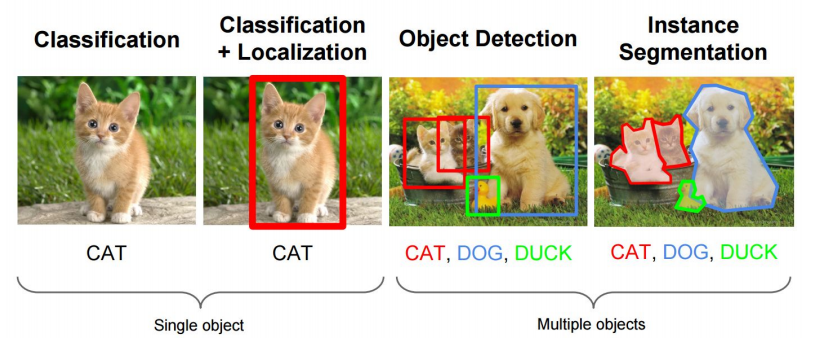

## 1.1. Localization Methods

- Histogram of oriented Gradients (HOG) with SVM

[figure not shown]

- Selective search

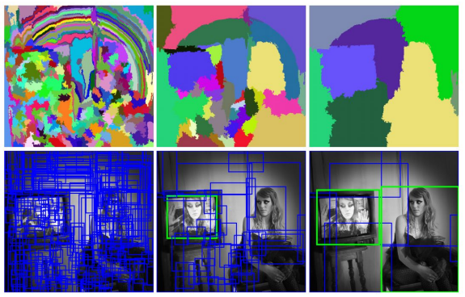

# 2. Object Detection Algorithms

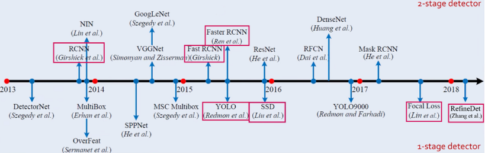

## 2.1. One-stage Object Detection

- YOLO

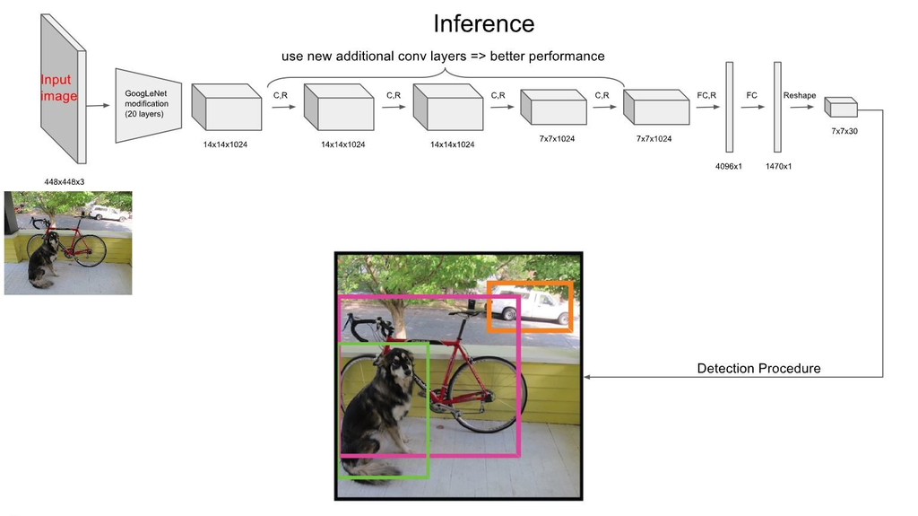

- SSD

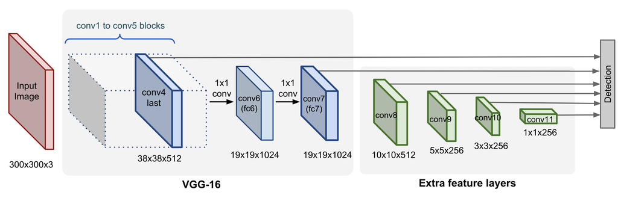

## 2.2. Two-stage Object Detection

- R-CNN

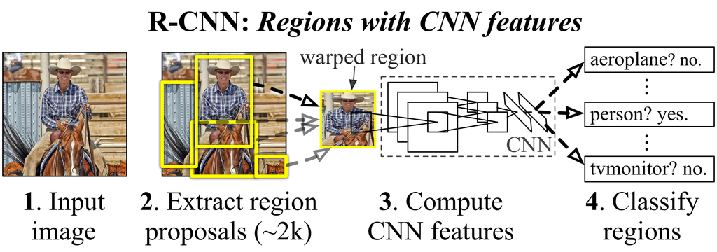

- Faster R-CNN

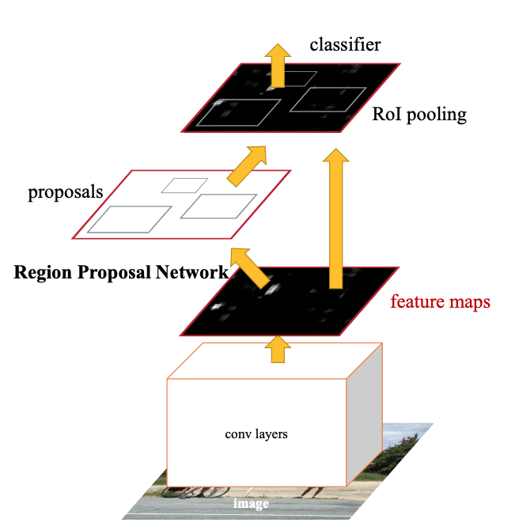

- Mask R-CNN

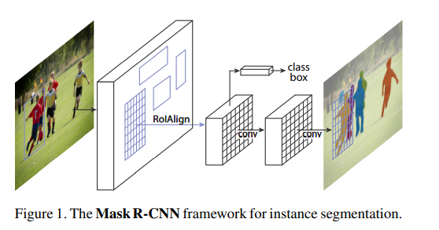

# 3. Example with Machinery Parts Dataset

- Simplified version of two-stage object detection model for tutorial

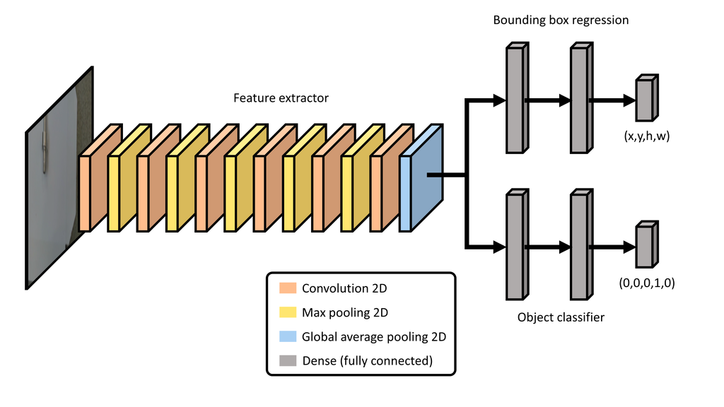

- 2-D convolution layers extract features from the input image.
- Extracted features are utilized for object bounding box detection and object classification
- Both classifier and bounding box regressor share the same features acuired from the 2-D convolution layers
- Dataset is available at: http://wordpress.csc.liv.ac.uk/smartlab/objectdetectionwork/

**Import Library**

```python
import tensorflow as tf
import numpy as np
import matplotlib.pyplot as plt
import matplotlib.patches as patches

%matplotlib inline
```

**Load Machinery Parts Dataset**

Download data from here

- [Object detection train images](https://www.dropbox.com/s/q018u8xjpgw1o08/object_detction_trn_data.npy?dl=1)
- [Object detection train labels](https://www.dropbox.com/s/n2tbpv711noece1/object_detction_trn_label.npy?dl=1)
- [Object detection test images](https://www.dropbox.com/s/sup33lt7hmpml49/object_detction_eval_data.npy?dl=1)
- [Object detection test labels](https://www.dropbox.com/s/2xi5naxkyw8a4cz/object_detction_eval_label.npy?dl=1)

```python
train_imgs = np.load('data_files/object_detction_trn_data.npy')
train_labels = np.load('data_files/object_detction_trn_label.npy')

test_imgs = np.load('data_files/object_detction_eval_data.npy')
test_labels = np.load('data_files/object_detction_eval_label.npy')

# input image: 240 by 320
# output label: class, x, y, h, w

classes = ['Axis',
           'Bearing',
           'Bearing_Box',
           'Distance_Tube',
           'F20_20_B']
```

```python
print(train_imgs.shape)
print(train_labels.shape)
print(test_imgs.shape)
print(test_labels.shape)
```

```
(240, 240, 320, 3)
(240, 5)
(60, 240, 320, 3)
(60, 5)
```

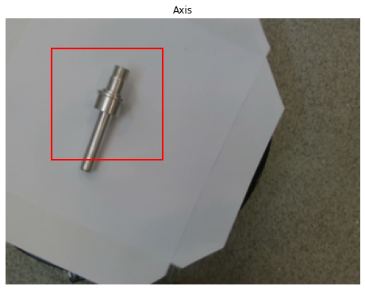

```python
idx = 138

train_img = train_imgs[idx]
c, x, y, h, w = train_labels[idx]

# rescaling
x, w = x*320, w*320
y, h = y*240, h*240

rect = patches.Rectangle((x, y),
                         w,
                         h,
                         linewidth = 2,
                         edgecolor = 'r',
                         facecolor = 'none')

fig, ax = plt.subplots(figsize = (8,8))
plt.title(classes[int(c)])
plt.imshow(train_img)
ax.add_patch(rect)
plt.axis('off')
plt.show()
```

```python
# rescaling output labels

train_labels = np.multiply(train_labels, [1, 320, 240, 320, 240])
test_labels = np.multiply(test_labels, [1, 320, 240, 320, 240])
```

**Define and Build an Object Detection Model**

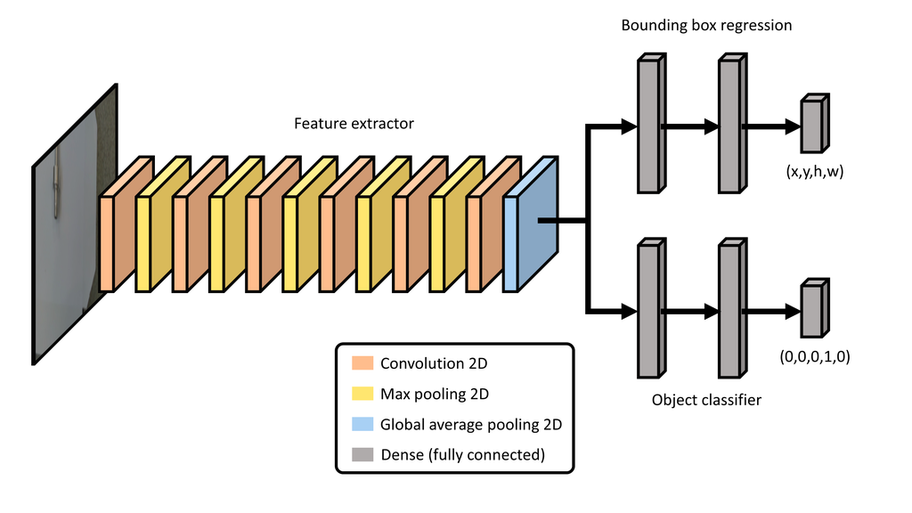

```python
feature_extractor = tf.keras.models.Sequential([
    tf.keras.layers.Conv2D(filters = 32,
                           kernel_size = (3,3),
                           activation = 'relu',
                           padding = 'SAME',
                           input_shape = (240, 320, 3)),

    tf.keras.layers.MaxPool2D(pool_size = (2,2)),

    tf.keras.layers.Conv2D(64, (3,3), activation = 'relu', padding = 'SAME'),

    tf.keras.layers.MaxPool2D((2,2)),

    tf.keras.layers.Conv2D(64, (3,3), activation = 'relu', padding = 'SAME'),

    tf.keras.layers.MaxPool2D((2,2)),

    tf.keras.layers.Conv2D(128, (3,3), activation = 'relu', padding = 'SAME'),

    tf.keras.layers.MaxPool2D((2,2)),

    tf.keras.layers.Conv2D(128, (3,3), activation = 'relu', padding = 'SAME'),

    tf.keras.layers.MaxPool2D((2,2)),

    tf.keras.layers.Conv2D(256, (3,3), activation = 'relu', padding = 'SAME'),

    tf.keras.layers.GlobalAveragePooling2D()
])
```

[output not shown]

```python
classifier = tf.keras.layers.Dense(256, activation = 'relu')(feature_extractor.output)
classifier = tf.keras.layers.Dense(256, activation = 'relu')(classifier)
classifier = tf.keras.layers.Dense(5, activation = 'softmax', name = 'cls')(classifier)
```

```python
bb_regressor = tf.keras.layers.Dense(256, activation = 'relu')(feature_extractor.output)
bb_regressor = tf.keras.layers.Dense(256, activation = 'relu')(bb_regressor)
bb_regressor = tf.keras.layers.Dense(4, name = 'bbox')(bb_regressor)
```

```python
object_detection = tf.keras.models.Model(inputs = feature_extractor.input,
                                         outputs = [classifier, bb_regressor])
```

```python
object_detection.summary()
```

```
Model: "model"
__________________________________________________________________________________________________
Layer (type)                    Output Shape         Param #     Connected to
==================================================================================================
conv2d_input (InputLayer)       [(None, 240, 320, 3) 0
__________________________________________________________________________________________________
conv2d (Conv2D)                 (None, 240, 320, 32) 896         conv2d_input[0][0]
__________________________________________________________________________________________________
max_pooling2d (MaxPooling2D)    (None, 120, 160, 32) 0           conv2d[0][0]
__________________________________________________________________________________________________
conv2d_1 (Conv2D)               (None, 120, 160, 64) 18496       max_pooling2d[0][0]
__________________________________________________________________________________________________
max_pooling2d_1 (MaxPooling2D)  (None, 60, 80, 64)   0           conv2d_1[0][0]
__________________________________________________________________________________________________
conv2d_2 (Conv2D)               (None, 60, 80, 64)   36928       max_pooling2d_1[0][0]
__________________________________________________________________________________________________
max_pooling2d_2 (MaxPooling2D)  (None, 30, 40, 64)   0           conv2d_2[0][0]
__________________________________________________________________________________________________
conv2d_3 (Conv2D)               (None, 30, 40, 128)  73856       max_pooling2d_2[0][0]
__________________________________________________________________________________________________
max_pooling2d_3 (MaxPooling2D)  (None, 15, 20, 128)  0           conv2d_3[0][0]
__________________________________________________________________________________________________
conv2d_4 (Conv2D)               (None, 15, 20, 128)  147584      max_pooling2d_3[0][0]
__________________________________________________________________________________________________
max_pooling2d_4 (MaxPooling2D)  (None, 7, 10, 128)   0           conv2d_4[0][0]
__________________________________________________________________________________________________
conv2d_5 (Conv2D)               (None, 7, 10, 256)   295168      max_pooling2d_4[0][0]
__________________________________________________________________________________________________
global_average_pooling2d (Globa (None, 256)          0           conv2d_5[0][0]
__________________________________________________________________________________________________
dense (Dense)                   (None, 256)          65792       global_average_pooling2d[0][0]
__________________________________________________________________________________________________
dense_2 (Dense)                 (None, 256)          65792       global_average_pooling2d[0][0]
__________________________________________________________________________________________________
dense_1 (Dense)                 (None, 256)          65792       dense[0][0]
__________________________________________________________________________________________________
dense_3 (Dense)                 (None, 256)          65792       dense_2[0][0]
__________________________________________________________________________________________________
cls (Dense)                     (None, 5)            1285        dense_1[0][0]
__________________________________________________________________________________________________
bbox (Dense)                    (None, 4)            1028        dense_3[0][0]
==================================================================================================
Total params: 838,409
Trainable params: 838,409
Non-trainable params: 0
__________________________________________________________________________________________________
```

**Define Losses and Optimization Configuration**

```python
object_detection.compile(optimizer = 'adam',
                         loss = {'cls': 'sparse_categorical_crossentropy',
                                 'bbox': 'mse'},
                         loss_weights = {'cls': 1,
                                         'bbox': 1})
```

```python
# divide labels to cls and bbox labels

train_cls = train_labels[:,:1]
train_bbox = train_labels[:,1:]

print(train_labels.shape)
print(train_cls.shape)
print(train_bbox.shape)
```

```
(240, 5)
(240, 1)
(240, 4)
```

```python
object_detection.fit(x = train_imgs,
                     y = {'cls': train_cls, 'bbox': train_bbox},
                     epochs = 100)
```

```
Train on 240 samples
```

```
<tensorflow.python.keras.callbacks.History at 0x2a835a95a88>
```

**Check Training Results**

```python
idx = 110

# true label
c_label, x_label, y_label, h_label, w_label = train_labels[idx]

rect_label = patches.Rectangle((x_label, y_label),
                               w_label,
                               h_label,
                               linewidth = 2,
                               edgecolor = 'r',
                               facecolor = 'none')

# predict
c_pred, bbox = object_detection.predict(train_imgs[[idx]])

x, y, h, w = bbox[0]
rect = patches.Rectangle((x, y),
                         w,
                         h,
                         linewidth = 2,
                         edgecolor = 'b',
                         facecolor = 'none')
```

```python
print(classes[int(c_label)])
print(classes[np.argmax(c_pred)])
```

```
Bearing
Bearing
```

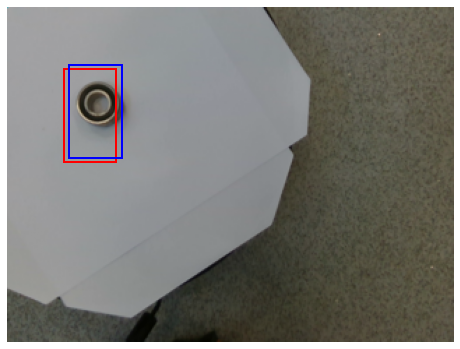

```python
fig, ax = plt.subplots(figsize = (8,8))
plt.imshow(train_imgs[idx])
ax.add_patch(rect_label)
ax.add_patch(rect)
plt.axis('off')
plt.show()
```

**Check Evaluation Results**

```python
idx = 50

# true label
c_label, x_label, y_label, h_label, w_label = test_labels[idx]

rect_label = patches.Rectangle((x_label, y_label),
                               w_label,
                               h_label,
                               linewidth = 2,
                               edgecolor = 'r',
                               facecolor = 'none')

# predict
c_pred, bbox = object_detection.predict(test_imgs[[idx]])

x, y, h, w = bbox[0]
rect = patches.Rectangle((x, y),
                         w,
                         h,
                         linewidth = 2,
                         edgecolor = 'b',
                         facecolor = 'none')
```

```python
print(classes[int(c_label)])
print(classes[np.argmax(c_pred)])
```

```
Distance_Tube
Distance_Tube
```

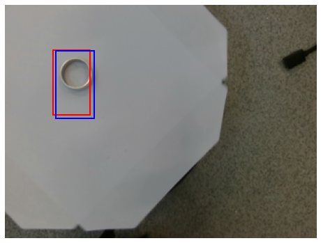

```python
fig, ax = plt.subplots(figsize = (8,8))
plt.imshow(test_imgs[idx])
ax.add_patch(rect_label)
ax.add_patch(rect)
plt.axis('off')
plt.show()
```

```python
%%javascript
$.getScript('https://kmahelona.github.io/ipython_notebook_goodies/ipython_notebook_toc.js')
```